# PA1_template.Rmd

## Loading and preprocessing data

First we should load the data to R studio

```r
dat = read.csv('activity.csv', header = T)
head(dat)
```

```
##   steps       date interval
## 1    NA 2012-10-01        0
## 2    NA 2012-10-01        5
## 3    NA 2012-10-01       10
## 4    NA 2012-10-01       15
## 5    NA 2012-10-01       20
## 6    NA 2012-10-01       25
```

Next, we should remove NA values by subseting our data and keep only the rows where each of the column has no NA values.

```r
clean <- subset(dat, (!is.na(dat$steps)) & (!is.na(dat$date)) & (!is.na(dat$interval)))
head(clean)
```

```
##     steps       date interval
## 289     0 2012-10-02        0
## 290     0 2012-10-02        5
## 291     0 2012-10-02       10
## 292     0 2012-10-02       15
## 293     0 2012-10-02       20
## 294     0 2012-10-02       25
```

## What is mean total number of steps taken per day?

For making our histogram, first we should summarize the steps by day

```r
library(dplyr)
spd <- clean %>% group_by(date) %>% summarise( tsteps = sum(steps))
head(spd)
```

```
## # A tibble: 6 x 2
##   date       tsteps
##   <fct>       <int>
## 1 2012-10-02    126
## 2 2012-10-03  11352
## 3 2012-10-04  12116
## 4 2012-10-05  13294
## 5 2012-10-06  15420
## 6 2012-10-07  11015
```

Then we are ready to make our first histogram and add the appropriate lines for mean and median

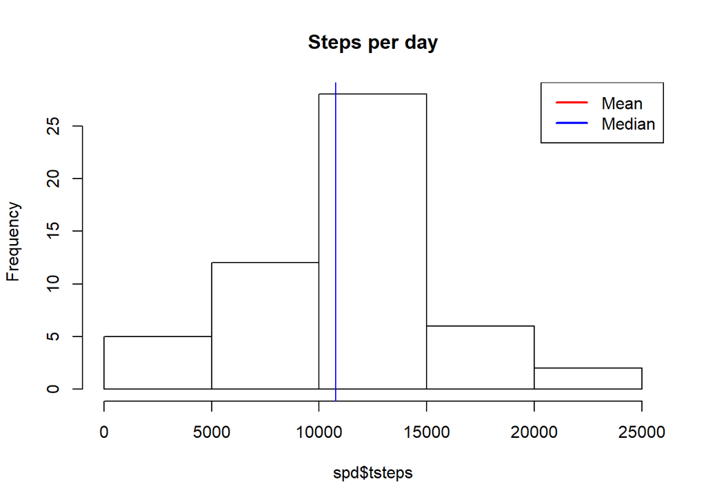

```r
hist(spd$tsteps, main = "Steps per day")

mean_spd <- round(mean(spd$tsteps), 1)
median_spd <- round(median(spd$tsteps), 1)

abline(v=mean_spd, lwd = 1, col = 'red')
abline(v=median_spd, lwd = 1, col = 'blue')

legend('topright', lty = 1, lwd = 2, col = c("red", "blue"), legend = c('Mean', 'Median'))
```

```r
paste0("Mean Value is ",mean_spd," and Median Value is ", median_spd)
```

```
## [1] "Mean Value is 10766.2 and Median Value is 10765"
```

## What is average daily activity

Our next goal is to plot the average daily activity pattern. Our first task is to aggregate the suitable measure as we did before

```r
aspd <- clean %>% group_by(interval) %>% summarise( tsteps = mean(steps))
head(aspd)
```

```
## # A tibble: 6 x 2
##   interval tsteps
##      <int>  <dbl>
## 1        0 1.72
## 2        5 0.340
## 3       10 0.132
## 4       15 0.151
## 5       20 0.0755
## 6       25 2.09
```

Then we can proceed in plotting our graph

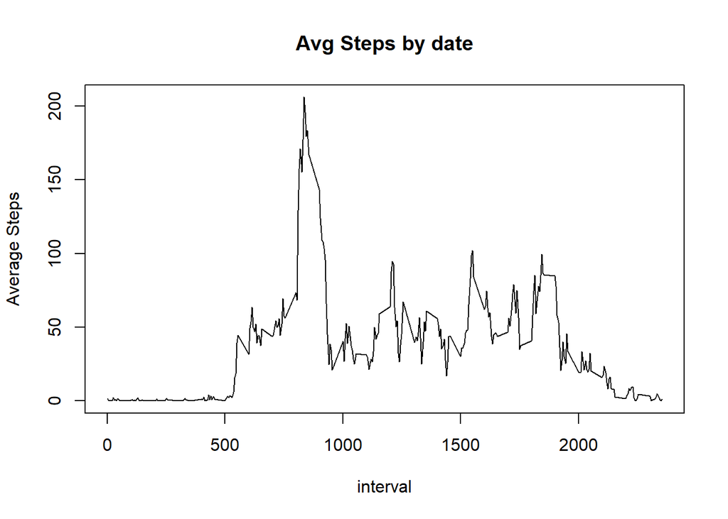

```r
with(aspd, plot(interval, tsteps, type = 'l', main = 'Avg Steps by date', ylab = 'Average Steps'))
```

Lastly we can find the interval with the maximum number of steps as shown below

```r
maxstepsint <- aspd[which.max(aspd$tsteps), 1]
maxsteps <- aspd[which.max(aspd$tsteps), 2]
paste0('Max number of steps is contained in the following interval ', maxstepsint, ' with average number of steps ', round(maxsteps))
```

```
## [1] "Max number of steps is contained in the following interval 835 with average number of steps 206"
```

## Inputing Missing Values

First we have to report the number of missing values

```r
sum(is.na(dat$steps))
```

```
## [1] 2304
```

Now we have to replace the missing values

```r
fixeddat <- dat
replace = function(x, y){
    if(is.na(x))
    {
        return (y)  #replace
    }
    else return (x)  #no replace
}

fixeddat$steps = mapply(replace,fixeddat$steps, mean(fixeddat$steps, na.rm = TRUE))
```

Now we can create two histograms for comparing the differences

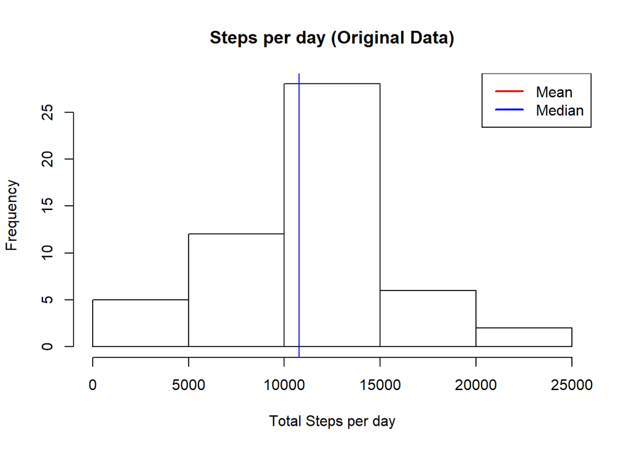

```r
org <- dat %>% group_by(date) %>% summarise( tsteps = sum(steps))
fixed <- fixeddat %>% group_by(date) %>% summarise( tsteps = sum(steps))

# orginal #

hist(org$tsteps, main = "Steps per day (Original Data)", xlab = "Total Steps per day")

mean_org <- round(mean(org$tsteps, na.rm = TRUE), 1)
median_org <- round(median(org$tsteps, na.rm = TRUE), 1)

abline(v=mean_org, lwd = 1, col = 'red')
abline(v=median_org, lwd = 1, col = 'blue')

legend('topright', lty = 1, lwd = 2, col = c("red", "blue"), legend = c('Mean', 'Median'))
```

```r
paste0("Mean Value is ",mean_org," and Median Value is ", median_org)
```

```
## [1] "Mean Value is 10766.2 and Median Value is 10765"
```

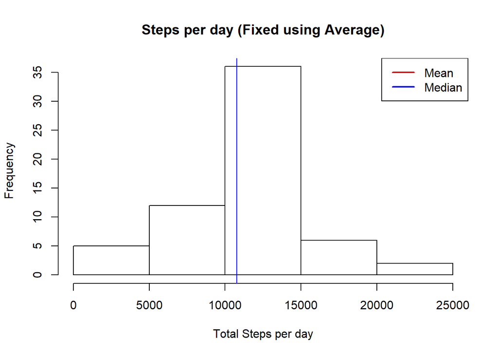

```r
#fixed #

hist(fixed$tsteps, main = "Steps per day (Fixed using Average)", xlab = "Total Steps per day")

mean_fixed <- round(mean(fixed$tsteps), 1)
median_fixed <- round(median(fixed$tsteps), 1)

abline(v=mean_fixed, lwd = 1, col = 'red')
abline(v=median_fixed, lwd = 1, col = 'blue')

legend('topright', lty = 1, lwd = 2, col = c("red", "blue"), legend = c('Mean', 'Median'))
```

```r
paste0("Mean Value is ",mean_fixed," and Median Value is ", median_fixed)
```

```
## [1] "Mean Value is 10766.2 and Median Value is 10766.2"
```

We can see that the differences are minor. In fact the mean value is almost the same in both cases. Median value is increased by a little in the case of the fixed Values

## Are there differences in activity patterns between weekdays and weekends?

First we should distinguish the weekends from the res of the days

```r
weekday = function(x){
    if(x %in% c('Saturday', 'Sunday')) return('Weekend')
    else return('Weekday')
}

clean$day = weekdays(as.Date(clean$date))
clean$dcat = as.factor(apply(as.matrix(clean$day), 1, weekday))

stepsbydaytype <- clean %>% group_by(interval, dcat) %>% summarise( tsteps = mean(steps))
```

Finally we can plot the 2 charts in order to compare the activity patterns for these 2 categories. (For creating them we will use lattice package and we will try to replicate the plot shown in the example)

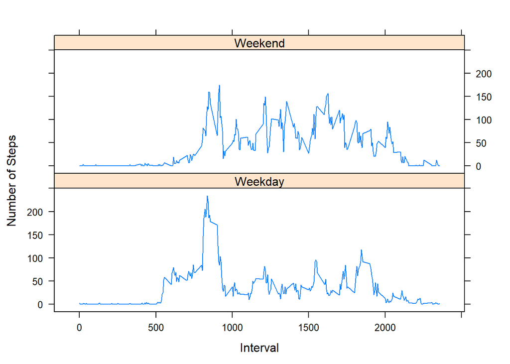

```r
library(lattice)
xyplot(tsteps ~ interval | dcat, data = stepsbydaytype,
      type = 'l',
      xlab = 'Interval',
      ylab = 'Number of Steps',
      layout = c(1,2))
```

For creating the images we used the following code for each case

```r
png('plot1.png', width=480, height=480)
dev.off()
```